# Ch4P2 Visualization Basics Part II

## 3.4 Colors for Discrete Variables

For qualitative/discrete variables, we can use the following functions to customize colors.

- Use pre-specified color palettes `virids` and `RColorBrewer`.
  - `scale_color_viridis_d()` for `virids` palettes such as `viridis`, `magma`, and etc.
  - `scale_color_brewer()` for `RColorBrewer` palettes such as `Set1`, `Set2`, and etc.
- Create a set of colors and assign them to each level of the variable.
  - `scale_color_manual()` for manually assigning colors to levels of discrete variables.

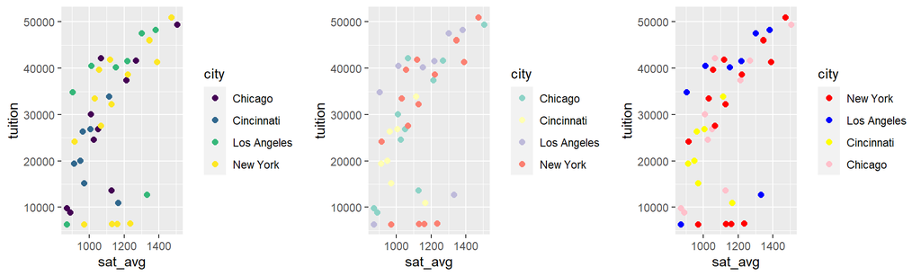

```r
g <- college %>%
  filter(city %in% c("New York", "Los Angeles", "Cincinnati", "Chicago")) %>%
  ggplot() +
  geom_point(aes(x=sat_avg, y=tuition, color = city), size=2)
g1 = g + scale_color_viridis_d()
g2 = g + scale_color_brewer(palette = "Set3")
g3 = g + scale_color_manual(breaks = c("New York", "Los Angeles", "Cincinnati", "Chicago"),
                              values = c("red", "blue", "yellow", "pink"))
grid.arrange(g1,g2,g3,ncol=3)
```

Note that we can set color in a similar way for other type of visualizations. Here are some example.

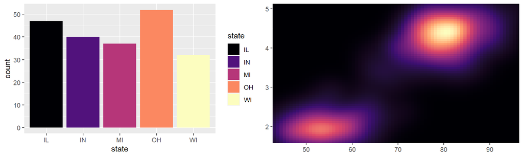

```r
g1=ggplot(filter(college, state %in% c("OH", "MI", "IN", "IL", "WI")),
          aes(x = state, fill=state)) +
  geom_bar() +
  scale_fill_viridis_d(option = "magma")
data("faithfuld")
erupt <- ggplot(faithfuld, aes(waiting, eruptions, fill = density)) +
  geom_raster() + scale_x_continuous(NULL, expand = c(0, 0)) + scale_y_continuous(NULL, expand = c(0, 0)) +
  theme(legend.position = "none")
g2 = erupt + scale_fill_viridis_c(option = "magma")
grid.arrange(g1,g2,ncol=2)
```

Note that `scale_color_continuous()` is equivalent to `scale_color_gradient()`. In addition, `scale_color_discrete()` is equivalent to `scale_color_hue()`.